# Math E-23C Term Project

Maria Cristina An, Daniel Lebedinsky, Julio Solis Arce

2022-05-06

## Glossary

- Rk – Rank
- G – Season Game
- W_E – opponent is from East or West
- Opp – Opponent
- W_L – Lakers team won or lost
- Tm – Lakers team Points
- Opp_pts – Opponent Points

# Lakers

- FG_LA – Field Goals
- FGA_LA – Field Goal Attempts
- FGpc_LA – Field Goal Percentage
- X3P_LA – 3-Point Field Goals
- X3PA_LA – 3-Point Field Goal Attempts
- X3Ppc_LA – 3-Point Field Goal Percentage
- FT_LA – Free Throws
- FTA_LA – Free Throw Attempts
- FTpc_LA – Free Throw Percentage
- ORB_LA – Offensive Rebounds
- TRB_LA – Total Rebounds
- AST_LA – Assists
- STL_LA – Steals
- BLK_LA – Blocks
- TOV_LA – Turnovers
- PF_LA – Personal Fouls

# Opponent

-FG – Opponent Field Goals

-FGA – Opponent Field Goal Attempts

-FGpc – Opponent Field Goal Percentage

-X3P – Opponent 3-Point Field Goals

-X3PA – Opponent 3-Point Field Goal Attempts

-X3Ppc – Opponent 3-Point Field Goal Percentage

-FT – Opponent Free Throws

-FTA – Opponent Free Throw Attempts

-FTpc – Opponent Free Throw Percentage

-ORB – Opponent Offensive Rebounds

-TRB – Opponent Total Rebounds

-AST – Opponent Assists

-STL – Opponent Steals

-BLK – Opponent Blocks

-TOV – Opponent Turnovers

-PF – Opponent Personal Fouls

## 1. Importing and cleaning data

Reference: https://www.basketball-reference.com/teams/LAL/2020/gamelog/

```r
#Import dataset
Lakers <- read.csv("Lakers\ 2019-20\ Game\ log.csv"); head(Lakers)
```

```
##   Rk G       Date W_E Opp W_L  Tm Opp_pts FG_LA FGA_LA FGpc_LA X3P_LA X3PA_LA
## 1  1 1 2019-10-22   W LAC   L 102     112    37     85   0.435     13      33
## 2  2 2 2019-10-25   W UTA   W  95      86    34     86   0.395      8      26
## 3  3 3 2019-10-27   E CHO   W 120     101    49     93   0.527     11      31
## 4  4 4 2019-10-29   W MEM   W 120      91    40     86   0.465      7      26
## 5  5 5 2019-11-01   W DAL   W 119     110    47     96   0.490      9      32
## 6  6 6 2019-11-03   W SAS   W 103      96    42     87   0.483      6      24
##   X3Ppc_LA FT_LA FTA_LA FTpc_LA ORB_LA TRB_LA AST_LA STL_LA BLK_LA TOV_LA PF_LA
## 1    0.394    15     21   0.714      9     41     20      4      7     14    24
## 2    0.308    19     24   0.792     11     42     19     14      9     14    21
## 3    0.355    11     14   0.786     10     47     30      7      8     13    22
## 4    0.269    33     39   0.846     10     54     25      9      8     18    19
## 5    0.281    16     21   0.762      6     41     24     11      7     11    21
## 6    0.250    13     19   0.684      7     46     21      8     10     18    22
##   FG FGA  FGpc X3P X3PA X3Ppc FT FTA  FTpc ORB TRB AST STL BLK TOV PF
## 1 42  81 0.519  11   31 0.355 17  24 0.708  11  45  24   8   5  14 25
## 2 29  70 0.414   8   25 0.320 20  21 0.952   3  40  19   8   2  22 25
## 3 35  91 0.385  10   35 0.286 21  23 0.913  13  45  19   7   4  14 20
## 4 31  95 0.326   7   34 0.206 22  23 0.957  13  46  20  10   3  21 27
## 5 40 102 0.392  14   36 0.389 16  23 0.696  18  61  23   5   1  22 21
## 6 33  83 0.398   6   25 0.240 24  29 0.828   8  47  23  11   4  17 18
```

```r
# Convert to proper date format
Lakers$Dates <- as.Date(Lakers$Date)
attach(Lakers)
```

## 2. and 3. Summary

```r
summary(Lakers)
```

```
##        Rk              G             Date               W_E
##  Min.   : 1.00   Min.   : 1.00   Length:92          Length:92
##  1st Qu.:12.00   1st Qu.:12.00   Class :character   Class :character
##  Median :25.50   Median :25.50   Mode  :character   Mode  :character
##  Mean   :30.29   Mean   :30.29
##  3rd Qu.:48.25   3rd Qu.:48.25
##  Max.   :71.00   Max.   :71.00
##      Opp                W_L                  Tm           Opp_pts
##  Length:92          Length:92          Min.   : 86.0   Min.   : 80.0
##  Class :character   Class :character   1st Qu.:104.0   1st Qu.:100.0
##  Mode  :character   Mode  :character   Median :114.0   Median :108.0
##                                        Mean   :113.3   Mean   :107.3
##                                        3rd Qu.:122.0   3rd Qu.:114.0
##                                        Max.   :142.0   Max.   :139.0
##      FG_LA           FGA_LA          FGpc_LA           X3P_LA
##  Min.   :29.00   Min.   : 74.00   Min.   :0.3510   Min.   : 2.00
##  1st Qu.:38.00   1st Qu.: 83.00   1st Qu.:0.4512   1st Qu.: 9.00
##  Median :43.00   Median : 87.00   Median :0.4855   Median :11.00
##  Mean   :42.04   Mean   : 87.32   Mean   :0.4815   Mean   :11.26
##  3rd Qu.:46.00   3rd Qu.: 91.00   3rd Qu.:0.5160   3rd Qu.:14.00
##  Max.   :55.00   Max.   :102.00   Max.   :0.5880   Max.   :19.00
##     X3PA_LA         X3Ppc_LA          FT_LA           FTA_LA
##  Min.   :19.00   Min.   :0.1050   Min.   : 7.00   Min.   : 8.00
##  1st Qu.:29.00   1st Qu.:0.2965   1st Qu.:14.00   1st Qu.:19.00
##  Median :32.00   Median :0.3435   Median :18.00   Median :24.00
##  Mean   :32.17   Mean   :0.3487   Mean   :17.95   Mean   :24.39
##  3rd Qu.:36.00   3rd Qu.:0.4042   3rd Qu.:23.00   3rd Qu.:29.00
##  Max.   :47.00   Max.   :0.5480   Max.   :33.00   Max.   :43.00
##     FTpc_LA           ORB_LA          TRB_LA          AST_LA
##  Min.   :0.4710   Min.   : 3.00   Min.   :25.00   Min.   :17.00
##  1st Qu.:0.6670   1st Qu.: 9.00   1st Qu.:41.00   1st Qu.:22.75
##  Median :0.7340   Median :11.00   Median :45.00   Median :25.00
##  Mean   :0.7371   Mean   :10.64   Mean   :45.36   Mean   :25.45
##  3rd Qu.:0.8135   3rd Qu.:12.00   3rd Qu.:49.00   3rd Qu.:28.25
##  Max.   :0.9470   Max.   :19.00   Max.   :62.00   Max.   :39.00
##      STL_LA           BLK_LA           TOV_LA          PF_LA
##  Min.   : 2.000   Min.   : 1.000   Min.   : 7.00   Min.   :13.00
##  1st Qu.: 6.750   1st Qu.: 4.000   1st Qu.:12.75   1st Qu.:18.00
##  Median : 9.000   Median : 6.000   Median :15.00   Median :21.50
##  Mean   : 8.489   Mean   : 6.304   Mean   :14.61   Mean   :21.16
```

[output cut: 22 more lines]

```
##  Max.   :1.0000   Max.   :18.000   Max.   :61.00   Max.   :37.00
##       STL              BLK              TOV              PF
##  Min.   : 2.000   Min.   : 0.000   Min.   : 5.00   Min.   :11.0
##  1st Qu.: 6.000   1st Qu.: 2.000   1st Qu.:12.00   1st Qu.:19.0
##  Median : 8.000   Median : 3.000   Median :15.00   Median :22.0
##  Mean   : 7.946   Mean   : 3.565   Mean   :14.83   Mean   :21.9
##  3rd Qu.:10.000   3rd Qu.: 5.000   3rd Qu.:17.25   3rd Qu.:25.0
##  Max.   :15.000   Max.   :10.000   Max.   :26.00   Max.   :32.0
##      Dates
##  Min.   :2019-10-22
##  1st Qu.:2019-12-07
##  Median :2020-01-28
##  Mean   :2020-03-16
##  3rd Qu.:2020-08-08
##  Max.   :2020-10-11
```

# 4. Number of columns and rows

```r
length(Lakers)
```

```
## [1] 41
```

```r
nrow(Lakers)
```

```
## [1] 92
```

```r
# Creating categorical columns
WonLost <- W_L == "W"; head(WonLost)
```

```
## [1] FALSE  TRUE  TRUE  TRUE  TRUE  TRUE
```

```r
sum(WonLost) # total wins
```

```
## [1] 68
```

# 1. Barplot of wins vs losses for our team

This plot shows the number of losses compared to the number wins by our team. The y-axis gives the count of wins and losses. The x-label answers the question “did the team win?”, FALSE means losing and TRUE means winning.

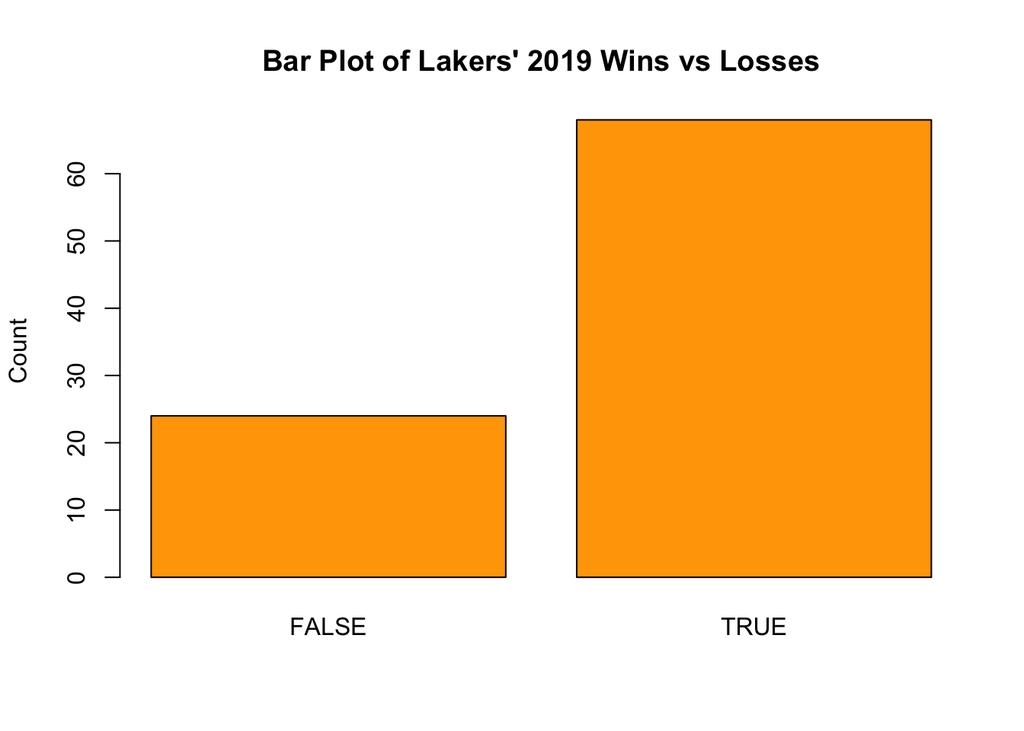

```r
barplot(table(WonLost), main = "Bar Plot of Lakers' 2019 Wins vs Losses", col = "orange", ylab="Count")
```

# Barplot of 3 point shots from our team

This plot shows the number of times the team scores a 3-point shot in a game. How often a 3-pointer occurs ranges from the minimum of 2 to a maximum of 19 in a single game.

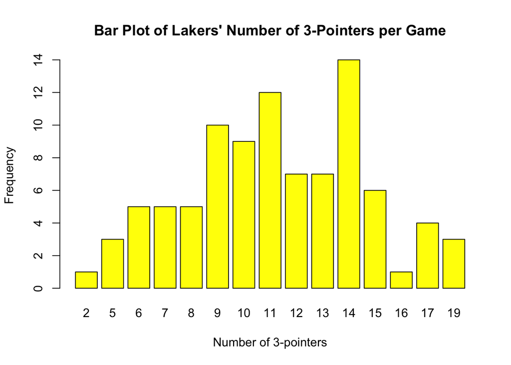

```r
barplot(table(X3P_LA), main = "Bar Plot of Lakers' Number of 3-Pointers per Game", xlab="Number of 3-pointers", ylab="Frequency", col = "yellow")
```

# Barplot of Opponent blocks

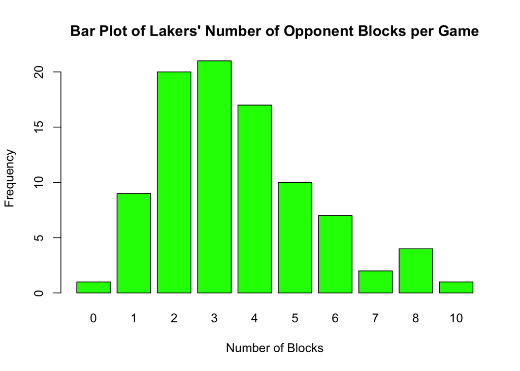

```r
barplot(table(BLK), main = "Bar Plot of Lakers' Number of Opponent Blocks per Game", xlab="Number of Blocks", ylab="Frequency", col = "green")
```

## 2. Histogram of 3 point shots

This is a histogram version of the barplot which shows the number of times the team scores a 3-point shot in a game. The data is the same, and so is the result, a 3-pointer event ranges from the minimum of 2 to a maximum of 19.

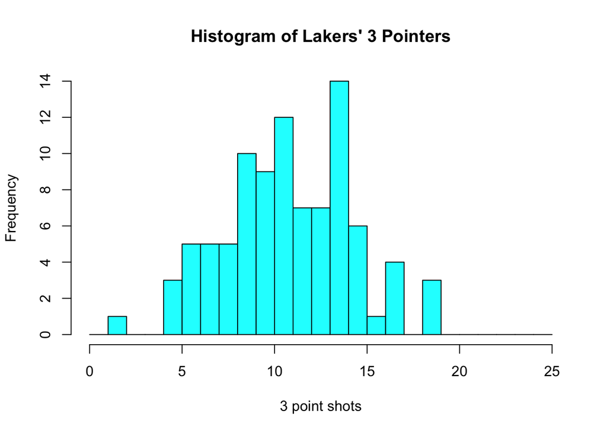

```r
hist(X3P_LA, xlab = "3 point shots", main = "Histogram of Lakers' 3 Pointers", col = "cyan", breaks=(0:25))
```

# Histogram of Opponent blocks

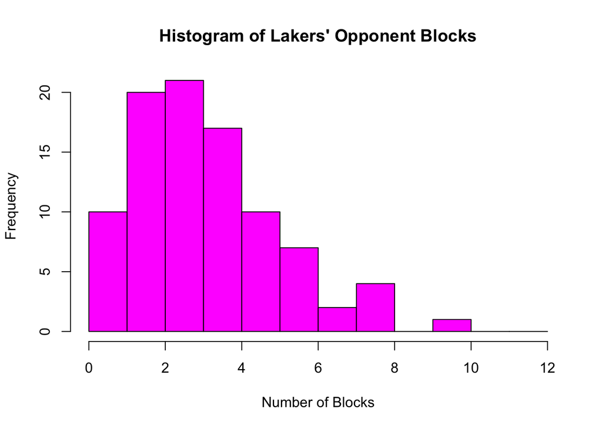

```r
hist(BLK, main = "Histogram of Lakers' Opponent Blocks", xlab="Number of Blocks", col = "magenta", breaks=(0:12))
```

# Histogram of our team’s number of Free Throws

This histogram shows the probability of the number of free throws done by our team in a game. The range is from a minimum of 7 to a maximum of 33 with a maximum density at 14 and 17.

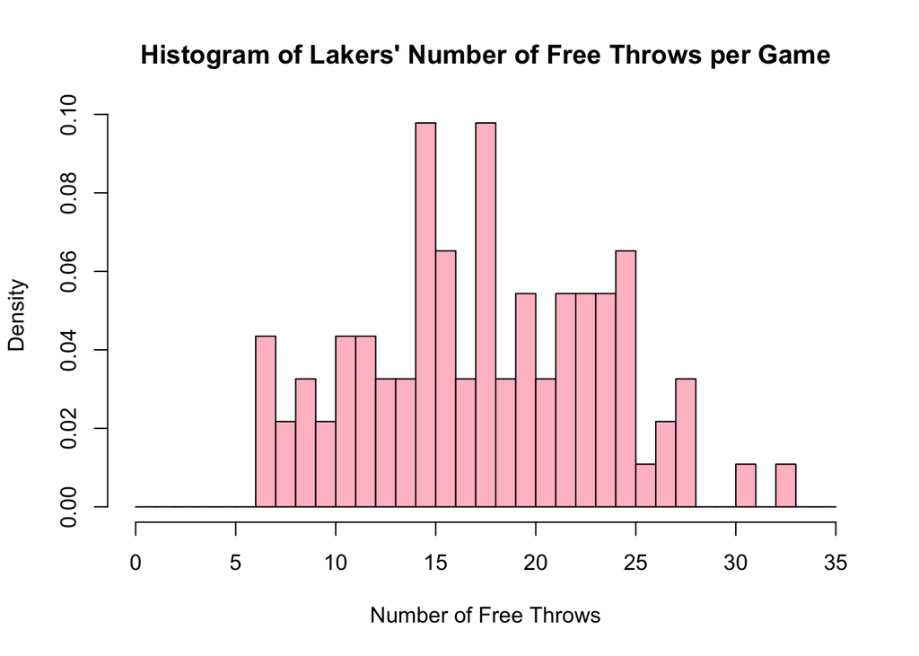

```r
hist(FT_LA, probability=TRUE, main="Histogram of Lakers' Number of Free Throws per Game", xlab="Number of Free Throws", col = "pink", breaks=(0:35)) # free throws from the team per game
```

## 3. Probability density graph overlay on the our team’s total number of rebounds in a game

Here we have our team’s probability of the total number of rebounds in a game. Ranging from a minimum of 25 to a maximum of 62, the graph seems like it came from a normal distribution. Overlaying a normal distribution shows like it does.

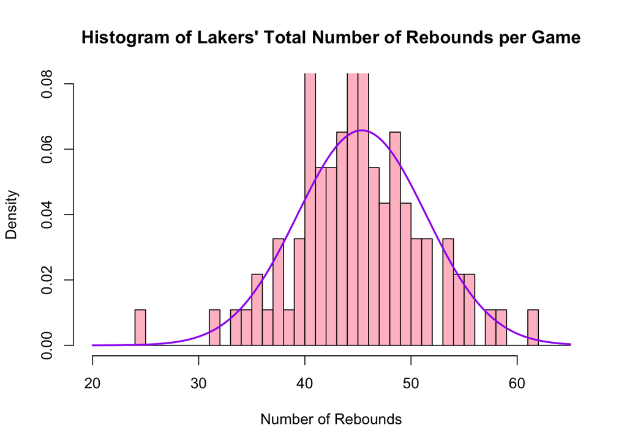

```r
mu<-mean(TRB_LA); stdv<- sd(TRB_LA)
hist(TRB_LA, probability=TRUE, main = "Histogram of Lakers' Total Number of Rebounds per Game", ylim=c(0,0.08), xlab="Number of Rebounds", col = "pink", breaks=(20:65))
# total rebounds per game
curve(dnorm(x, mu, stdv), col="purple", add=TRUE, lwd=2)
```

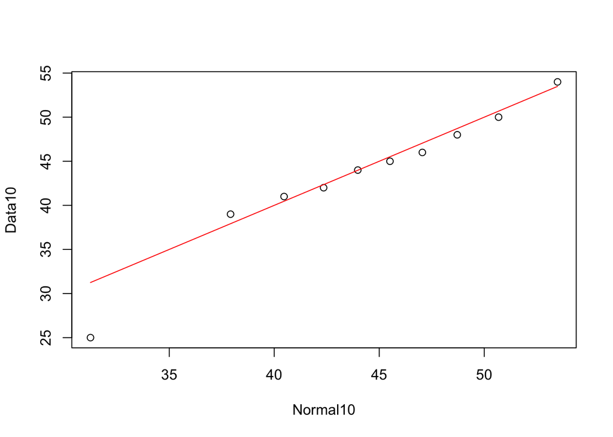

```r
#Appears to be a normal distribution. We will compare it with Deciles and a Q-Q plot
Normal10<- qnorm(seq(0.01, 0.99, by=0.1), mean=mu, sd=stdv);
Data10<- quantile(TRB_LA, seq(0.01, 0.99, by=0.1), type=2);
plot(Normal10, Data10)
f<-function(x) x
curve(f, col="red", add=TRUE)
```

```r
#Our data does not differ much from the Normal Distribution, except in the first decile.
```

# Probability density graph on the our team’s scores in a game

We go back to our histogram of our team’s score and its probability in a game. It also seems as if it fits a normal distribution like it shows with a normal distribution overlay. We can provide more proof later with a chi-square goodness of fit test.

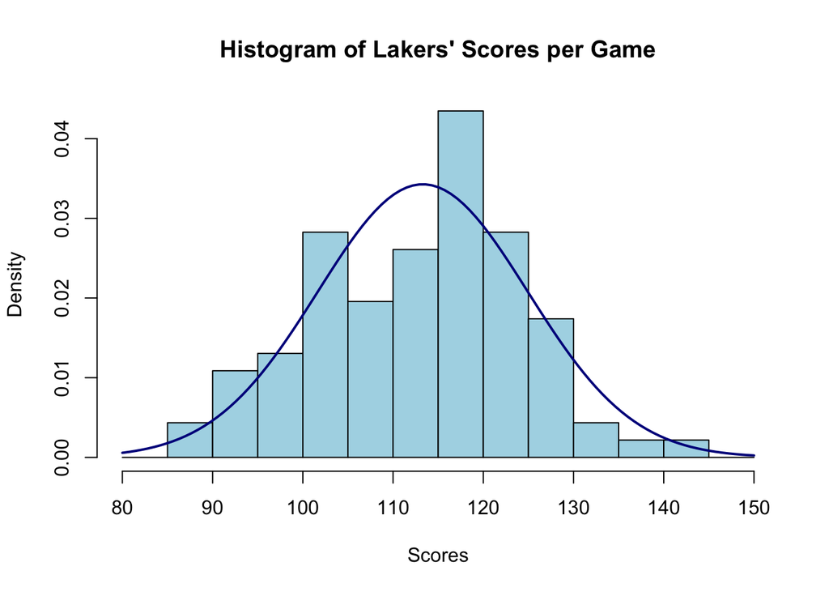

```r
mu<-mean(Tm); stdv<-sd(Tm)
hist(Tm,breaks=seq(from=80, to = 150, by =5), probability=TRUE, main = "Histogram of Lakers' Scores per Game", xlab="Scores", col = "light blue") # team's score frequencies
curve(dnorm(x, mu, stdv), col="dark blue", add=TRUE, lwd=2)
```

```r
#Binning and Chisq test to compare this histogram to a Normal Distribution
dec <- qnorm(seq(0.0, 1, by = 0.1), mu, stdv); dec   #10 bins
```

```
##  [1]      -Inf  98.37651 103.49720 107.18957 110.34458 113.29348 116.24238
##  [8] 119.39738 123.08976 128.21045       Inf
```

```r
Exp <- rep(length(Tm)/10,10); Exp     #expected scores per bin
```

```
##  [1] 9.2 9.2 9.2 9.2 9.2 9.2 9.2 9.2 9.2 9.2
```

```r
#Now we can count how many scores are in each bin
binscores <- numeric(10)
for (i in 1:10)
  binscores[i] <- sum((Tm >= dec[i]) & (Tm <= dec[i+1]) ); binscores
```

```
##  [1] 10 10 11  4  8  8 11 11 11  8
```

```r
#Test for uniformity using chi square.
Chi2 <- sum((binscores - Exp)^2/Exp); Chi2
```

```
## [1] 4.956522
```

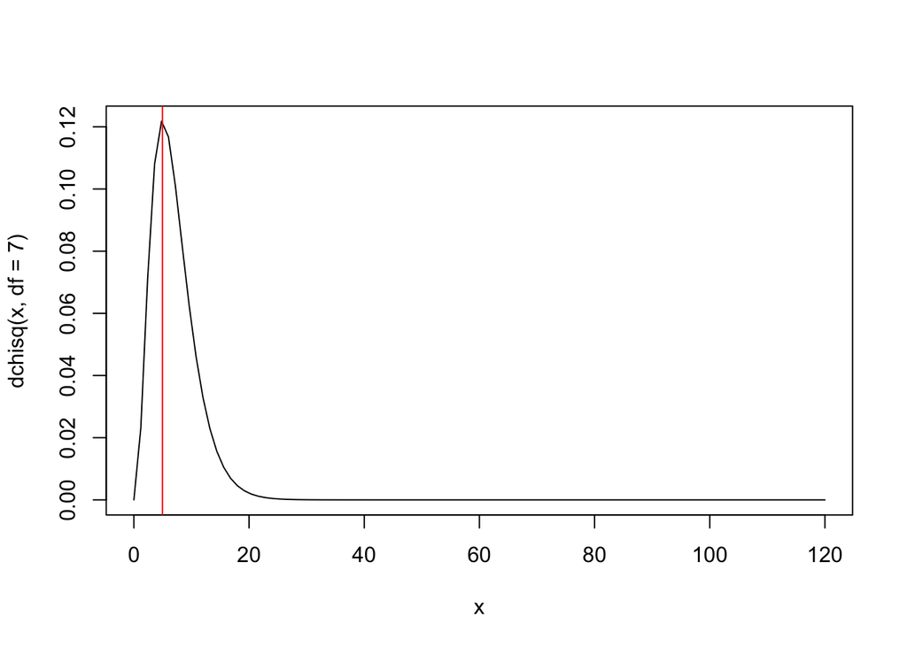

```r
#There were 10 bins. We estimated 2 parameters (mu and stdv), which costs two degrees of freedom
#Also we "made the totals match", costing another 1. So there are 10-2-1=7 df.
curve(dchisq(x, df = 7), from = 0, to = 120 )
abline(v=Chi2, col = "red")
```

```r
#The probability of this chi-square value is relatively large
#The normal distribution was a good model
```